# index

2024-08-25

We will be predicting the likelihood a customer will leave the company otherwise known as ‘churn’

```r
telco <- read.csv("https://docs.google.com/spreadsheets/d/1GbUzso0rHde2YjI3UDAVhJLgAIPz26uIoGL6EdFwSQw/export?format=csv", stringsAsFactors = TRUE)

names(telco)
```

```
##  [1] "Gender"           "SeniorCitizen"    "Partner"          "Dependents"       "tenure"           "PhoneService"     "MultipleLines"    "InternetService"  "OnlineSecurity"   "OnlineBackup"
## [11] "DeviceProtection" "TechSupport"      "StreamingTV"      "StreamingMovies"  "Contract"         "PaperlessBilling" "PaymentMethod"    "MonthlyCharges"   "TotalCharges"     "Churn"
```

```r
splits <- initial_split(telco)

telco_train <- training(splits)
telco_test <- testing(splits)
```

```r
telco_recipe <- recipe(Churn ~ ., data = telco_train) %>%
  step_YeoJohnson(all_numeric_predictors()) %>%
  step_dummy(all_nominal_predictors()) %>%
  step_corr(all_numeric_predictors()) %>%
  step_lincomb(all_numeric_predictors()) %>%
  step_nzv(all_numeric_predictors())

telco_recipe %>%
  prep()
```

```
## ── Recipe ──────────────────────────────────────────────────────────────────────────────────────────────────────────────────────────────────────────────────────────────────────────────────────────────
```

```
## ── Inputs
```

```
## Number of variables by role
```

```
## outcome:    1
## predictor: 19
```

```
## ── Training information
```

```
## Training data contained 5274 data points and no incomplete rows.
```

```
## ── Operations
```

```
## • Yeo-Johnson transformation on: tenure, MonthlyCharges, TotalCharges | Trained
```

```
## • Dummy variables from: Gender, SeniorCitizen, Partner, Dependents, PhoneService, MultipleLines, InternetService, OnlineSecurity, OnlineBackup, DeviceProtection, TechSupport, ... | Trained
```

```
## • Correlation filter on: TotalCharges, PhoneService_Yes, InternetService_No, OnlineSecurity_No.internet.service, OnlineBackup_No.internet.service, ... | Trained
```

```
## • Linear combination filter removed: <none> | Trained
```

```
## • Sparse, unbalanced variable filter removed: <none> | Trained
```

Using the GLMNET and forest model here with some values.

```r
telco_glmnet <- logistic_reg(
  engine = "glmnet",
  penalty = 0.01,
  mixture = 0.5
)

telco_forest <- rand_forest(
  mode = "classification",
  mtry = 5
) %>% set_engine(engine = "ranger", importance = "impurity")

# ------------------------------------------------------------------------------

telco_glmnet_workflow <- workflow() %>%
  add_recipe(telco_recipe) %>%
  add_model(telco_glmnet)

telco_forest_workflow <- workflow() %>%
  add_recipe(telco_recipe) %>%
  add_model(telco_forest)

# ------------------------------------------------------------------------------

fit_glmnet <- telco_glmnet_workflow %>%
  fit(telco_train)

fit_forest <- telco_forest_workflow %>%
  fit(telco_train)
```

Finding the five most important features for prediction

Here we notice the features of importance differ between the two models. The two features that remain in common between the two are InternetService_Fiber.optic and Contract_Two.year

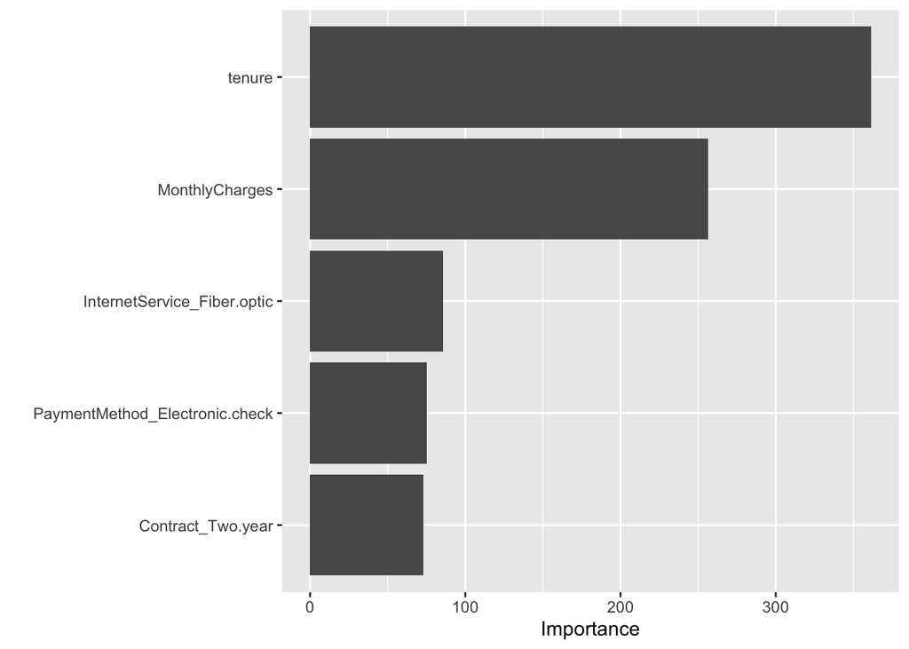

```r
vip_telco_forest <- telco_forest_workflow %>%
  finalize_workflow(telco_forest_workflow) %>%
  fit(telco_train)

vip(vip_telco_forest, num_features = 5)
```

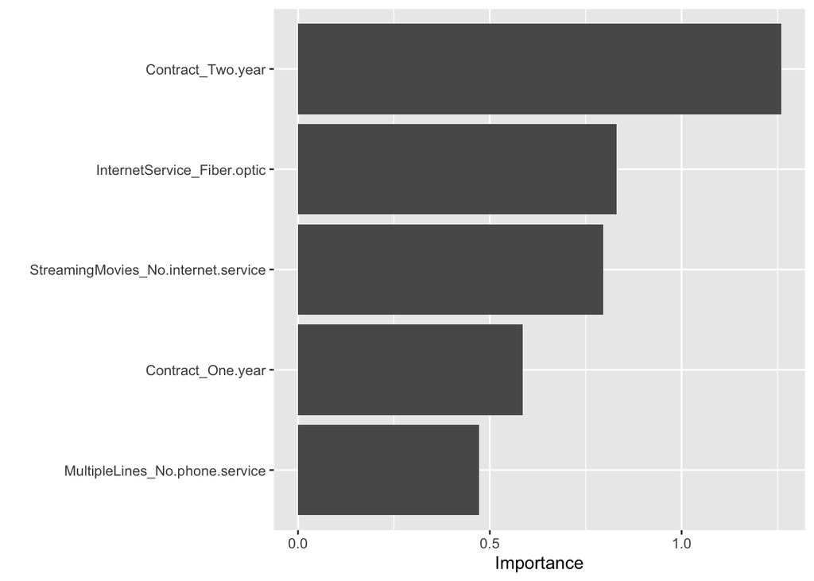

```r
vip_telco_glmnet <- telco_glmnet_workflow %>%
  finalize_workflow(telco_glmnet_workflow) %>%
  fit(telco_train)

vip(vip_telco_glmnet, num_features = 5)
```

Let’s look into how contract is related to churn since this was identified as most important for glmnet model and is of importance in the forest model.

```r
telco$Contract
```

[output not shown]

[output cut: 572 more lines]

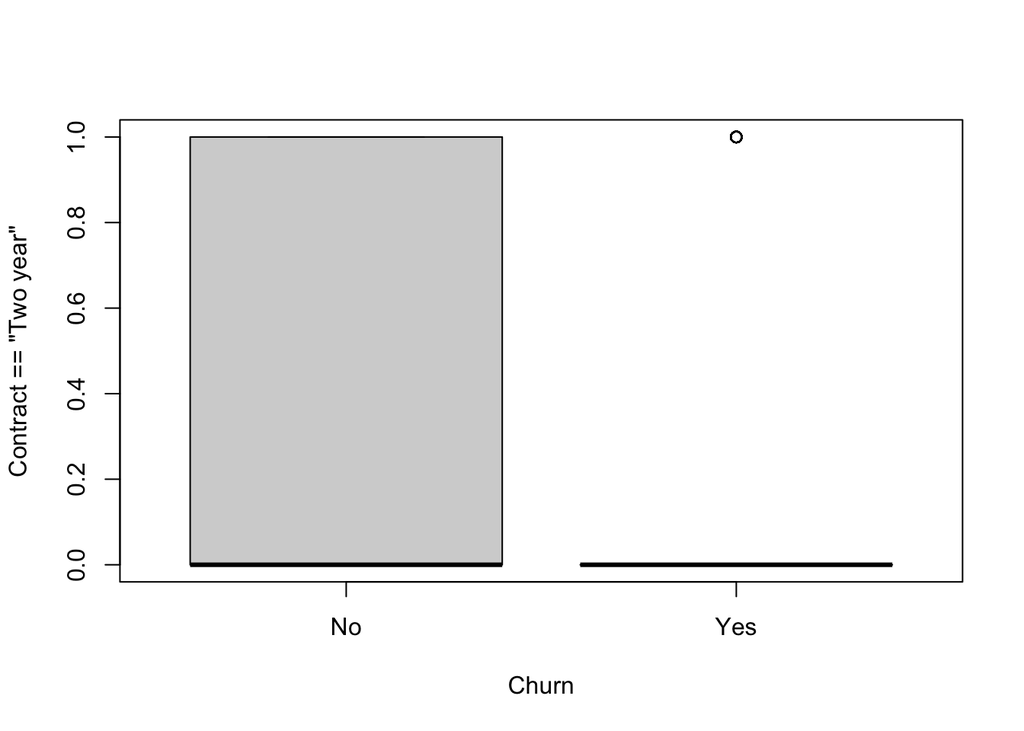

```r
boxplot(Contract=="Two year" ~ Churn, data = telco)
```

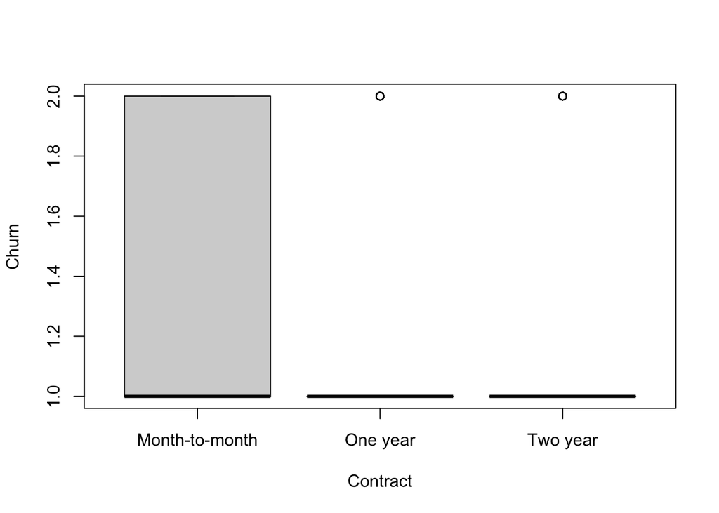

```r
boxplot(Churn~Contract, data = telco)
```

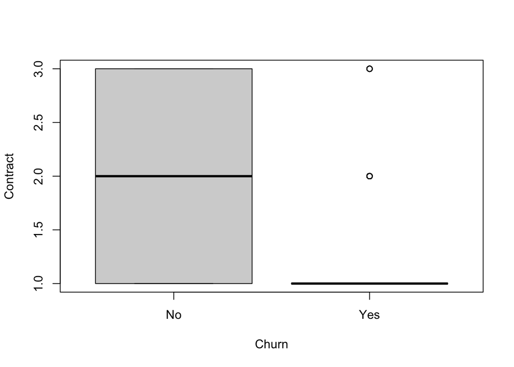

```r
boxplot(Contract~Churn, data=telco)
```

Let’s look into TotalCharges as well…

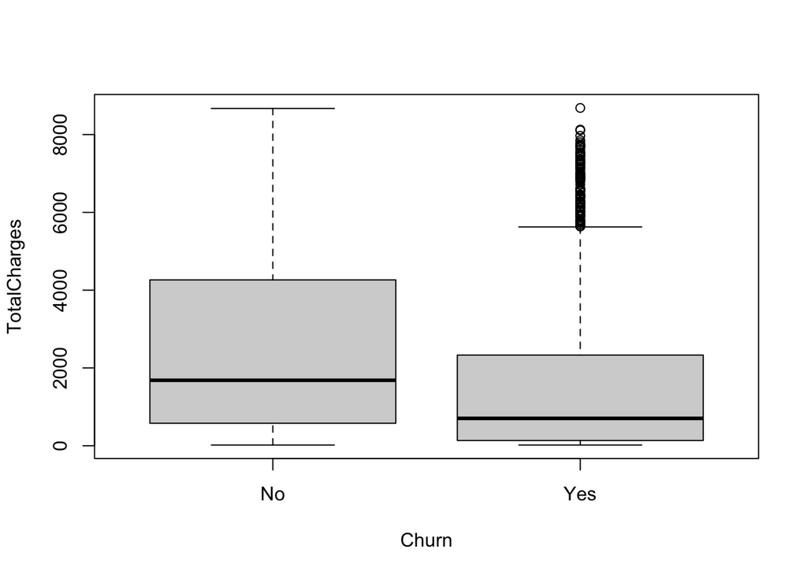

```r
boxplot(TotalCharges~Churn, data=telco)
```

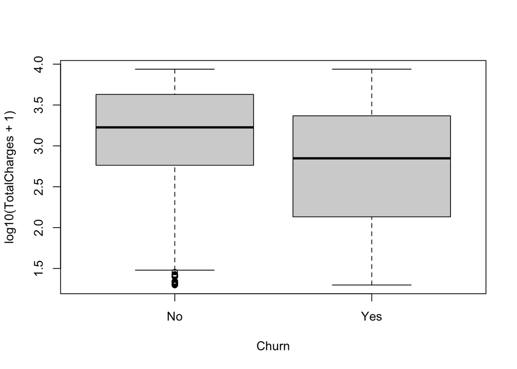

```r
boxplot(log10(TotalCharges+1)~Churn, data=telco)
```

Let’s use rand_rows to make our predictions on.

```r
set.seed(1337)
rand_rows <- bind_rows(
  telco_test %>% filter(Churn == "Yes") %>% sample_n(1),
  telco_test %>% filter(Churn == "No") %>% sample_n(1),
)
rand_rows$Churn
```

```
## [1] Yes No
## Levels: No Yes
```

```r
fit_glmnet %>%
  predict(rand_rows, type = "prob" )
```

```
## # A tibble: 2 × 2
##   .pred_No .pred_Yes
##      <dbl>     <dbl>
## 1    0.469     0.531
## 2    0.860     0.140
```

```r
fit_forest %>%
  predict(rand_rows, type = "prob")
```

```
## # A tibble: 2 × 2
##   .pred_No .pred_Yes
##      <dbl>     <dbl>
## 1    0.442    0.558
## 2    0.901    0.0988
```

```r
glmnet_train_preds <- bind_cols(
  predict(fit_glmnet, telco_train),
  predict(fit_glmnet, telco_train, type = "prob"),
  telco_train
)

glmnet_test_preds <- bind_cols(
  predict(fit_glmnet, telco_test),
  predict(fit_glmnet, telco_test, type = "prob"),
  telco_test
)

# ------------------------------------------------------------------------------

forest_train_preds <- bind_cols(
  predict(fit_forest, telco_train),
  predict(fit_forest, telco_train, type = "prob"),
  telco_train
)

forest_test_preds <- bind_cols(
  predict(fit_forest, telco_test),
  predict(fit_forest, telco_test, type = "prob"),
  telco_test
)
```

```r
glmnet_train_preds %>%
  metrics(Churn, .pred_class, .pred_Yes)
```

```
## # A tibble: 4 × 3
##   .metric     .estimator .estimate
##   <chr>       <chr>          <dbl>
## 1 accuracy    binary         0.805
## 2 kap         binary         0.468
## 3 mn_log_loss binary         1.81
## 4 roc_auc     binary         0.150
```

```r
glmnet_test_preds %>%
  metrics(Churn, .pred_class, .pred_Yes)
```

```
## # A tibble: 4 × 3
##   .metric     .estimator .estimate
##   <chr>       <chr>          <dbl>
## 1 accuracy    binary         0.815
## 2 kap         binary         0.454
## 3 mn_log_loss binary         1.88
## 4 roc_auc     binary         0.151
```

```r
glmnet_test_preds %>%
  conf_mat(Churn, .pred_class)
```

```
##           Truth
## Prediction   No  Yes
##        No  1216  210
##        Yes  116  216
```

```r
forest_train_preds %>%
  metrics(Churn, .pred_class, .pred_Yes)
```

```
## # A tibble: 4 × 3
##   .metric     .estimator .estimate
##   <chr>       <chr>          <dbl>
## 1 accuracy    binary        0.909
## 2 kap         binary        0.761
## 3 mn_log_loss binary        2.35
## 4 roc_auc     binary        0.0255
```

```r
forest_test_preds %>%
  metrics(Churn, .pred_class, .pred_Yes)
```

```
## # A tibble: 4 × 3
##   .metric     .estimator .estimate
##   <chr>       <chr>          <dbl>
## 1 accuracy    binary         0.809
## 2 kap         binary         0.443
## 3 mn_log_loss binary         2.06
## 4 roc_auc     binary         0.157
```

```r
forest_test_preds %>%
  conf_mat(Churn, .pred_class)
```

```
##           Truth
## Prediction   No  Yes
##        No  1205  209
##        Yes  127  217
```

Below we have the top three customer in this data that are predicted most likely to churn.

```r
top_3_customers <- glmnet_test_preds %>%
  arrange(desc(.pred_Yes)) %>%
  head(3)
top_3_customers
```

```
## # A tibble: 3 × 23
##   .pred_class .pred_No .pred_Yes Gender SeniorCitizen Partner Dependents tenure PhoneService MultipleLines InternetService OnlineSecurity OnlineBackup DeviceProtection TechSupport StreamingTV
##   <fct>          <dbl>     <dbl> <fct>  <fct>         <fct>   <fct>       <int> <fct>        <fct>         <fct>           <fct>          <fct>        <fct>            <fct>       <fct>
## 1 Yes            0.135     0.865 Male   Yes           No      No              2 Yes          Yes           Fiber optic     No             No           No               No          Yes
## 2 Yes            0.135     0.865 Male   Yes           No      No              2 Yes          Yes           Fiber optic     No             No           No               No          Yes
## 3 Yes            0.158     0.842 Female Yes           No      No              2 Yes          Yes           Fiber optic     No             No           No               No          No
## # ℹ 7 more variables: StreamingMovies <fct>, Contract <fct>, PaperlessBilling <fct>, PaymentMethod <fct>, MonthlyCharges <dbl>, TotalCharges <dbl>, Churn <fct>
```